# COMPSCIX 415.2 Homework 3

Praveen Chander

June 23, 2018

# 3.8.1

## Q1

In the Question, The plot is skewed between these 2 continuous variables, Therefore instead of using geom_plot(), if geom_jitter() is used the skeness is reduced and also can be plotted w.r.t a **dimensional variable** like “Displacement” as FACTOR for the color

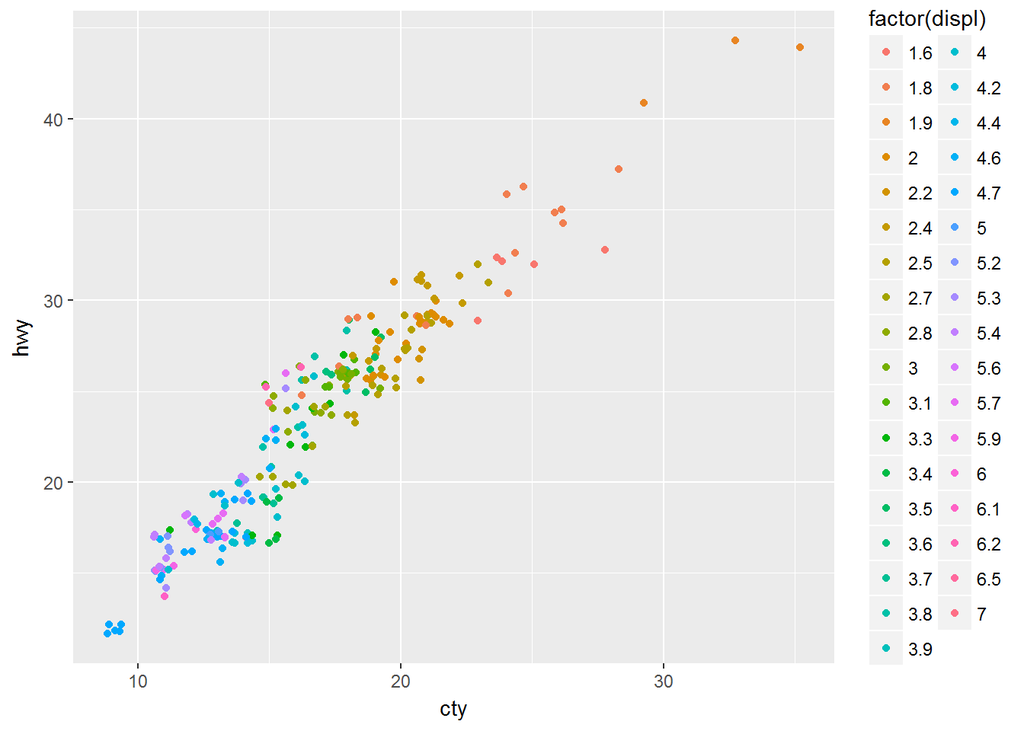

```r
ggplot(data=mpg, mapping = aes(x=cty, y=hwy)) +geom_jitter(aes(colour=factor(displ)))
```

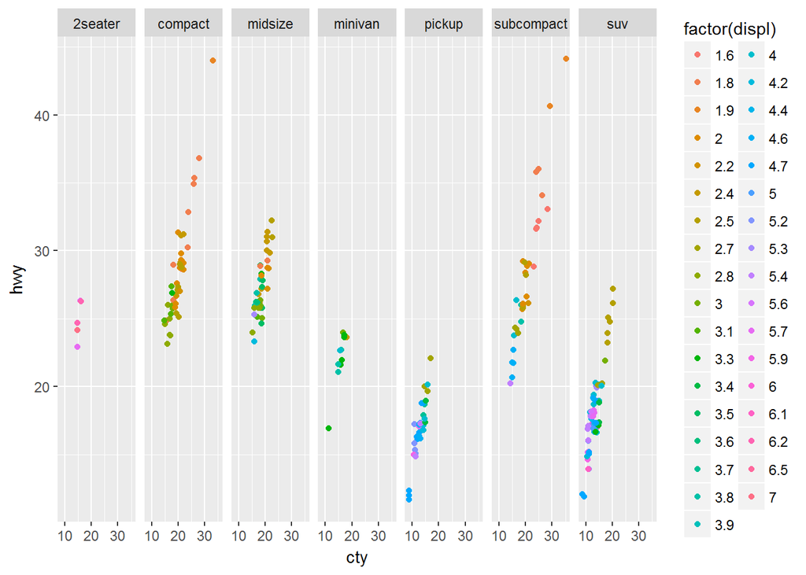

```r
# This can still more be grouped by class of the vehicle
ggplot(data=mpg, mapping = aes(x=cty, y=hwy)) +geom_jitter(aes(colour=factor(displ))) + facet_wrap(~class, nrow = 1, ncol = 7)
```

## Q2

The Parameters that control the amount of jittering are WIDTH & HEIGHT

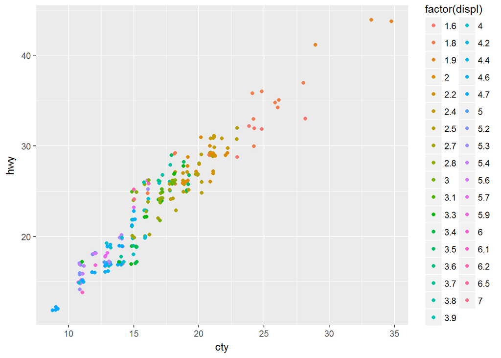

```r
ggplot(mpg, aes(cty, hwy)) + geom_jitter(aes(colour=factor(displ)), width = 0.25, height = 0.25)
```

## Q3

–> Unlike geom_jitter(), geom_count() exhibit a **skewed** plot. –> Count has to be plotted w.r.t any **dimensional** categorical variable. –> For geom_count() you can plot a graph with *point SIZE propotional with a count of a variable*. This is Best used in conjunction with scale_size_area. Larger counts in a particular portion has a big size point plotted

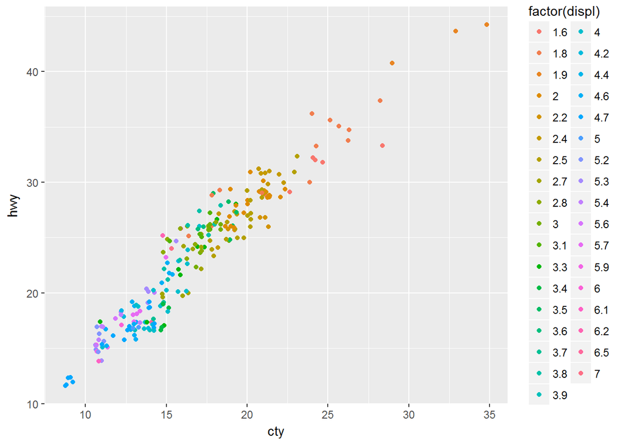

```r
ggplot(mpg, aes(cty, hwy)) + geom_jitter(aes(colour=factor(displ)))
```

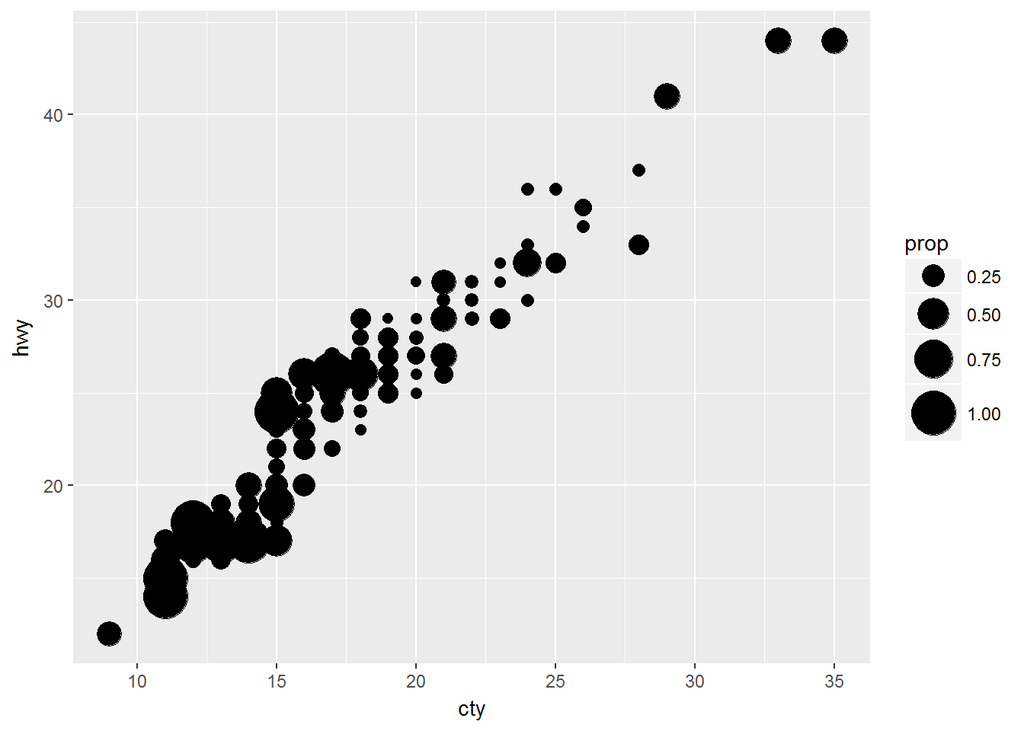

```r
ggplot(mpg, aes(cty, hwy)) + geom_count(aes(size = ..prop.., group = displ)) + scale_size_area(max_size = 10)
```

## Q4

Default position adjustment for geom_boxplot() is **position=‘dodge’**

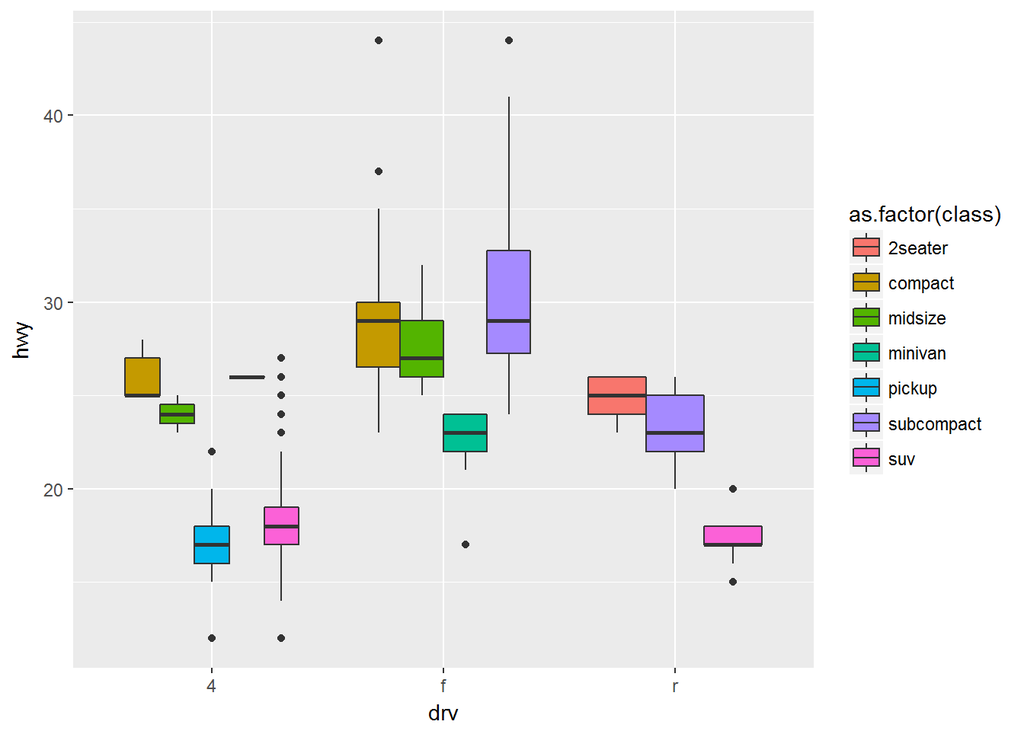

```r
X <- ggplot(data = mpg, mapping = aes(x=drv, y=hwy, fill=as.factor(class)))
X + geom_boxplot() # with no position
```

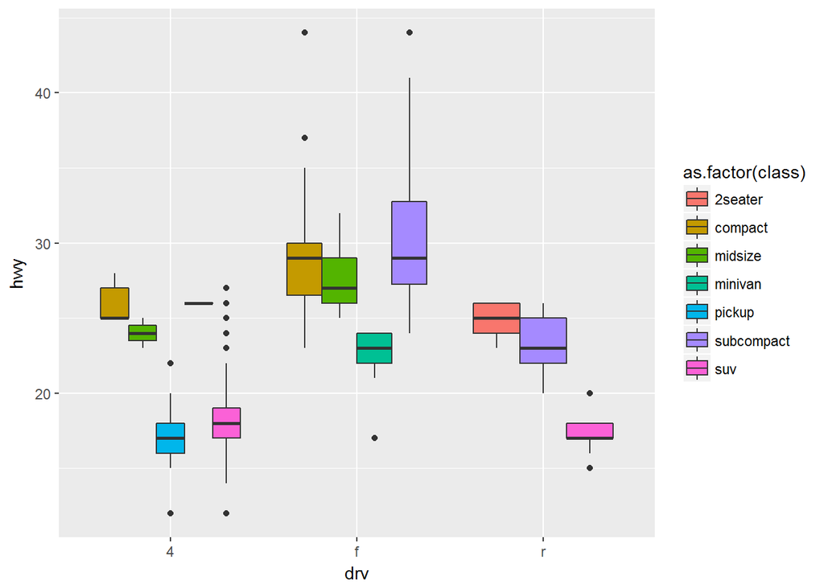

```r
X + geom_boxplot(position='dodge') # with dodge, looks the same as default
```

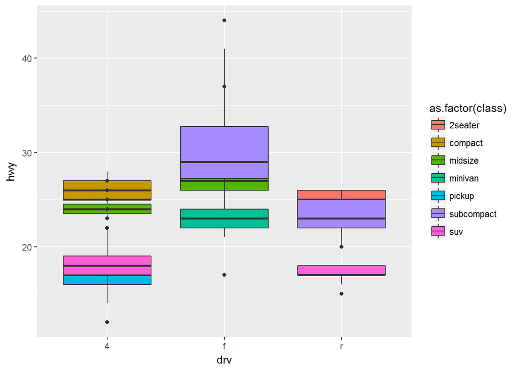

```r
X + geom_boxplot(position='identity')
```

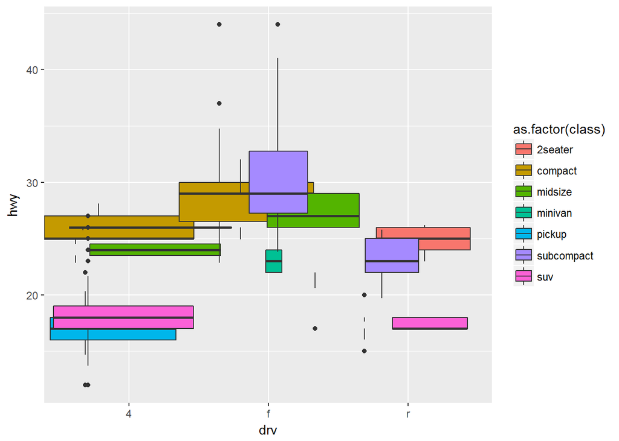

```r
X + geom_boxplot(position='jitter')
```

# 3.9.1

## Q2

labs() when set NULL the labels are not displayed, else will display to the set values for the individual values of **X and Y labels** as below

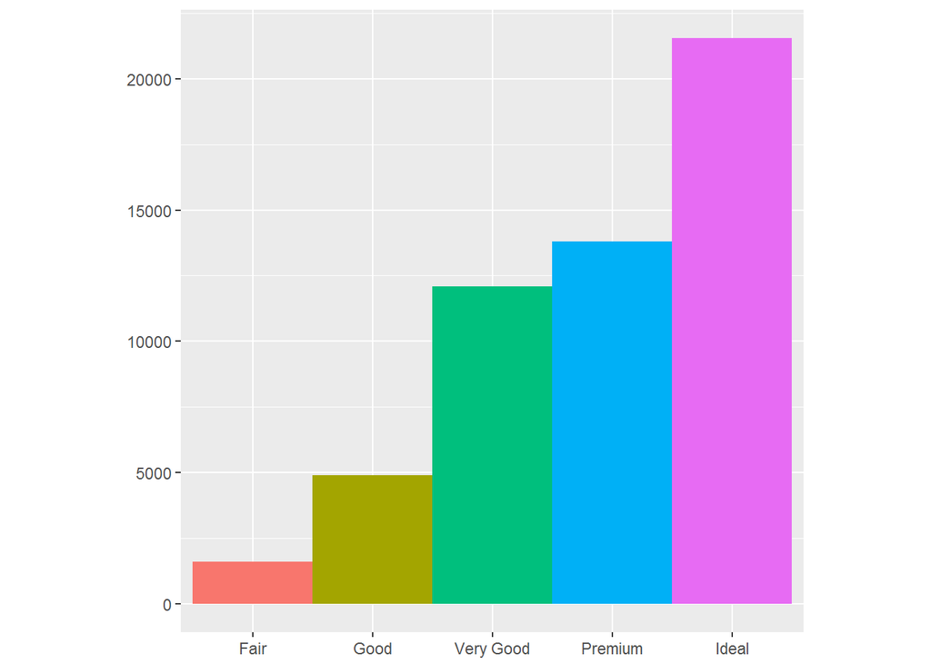

```r
# With labs()
bar <- ggplot(data = diamonds) +
  geom_bar(
    mapping = aes(x = cut, fill = cut),
    show.legend = FALSE,
    width = 1
  ) +
  theme(aspect.ratio = 1) +
  labs(x = NULL, y = NULL)

# without labs()
bar2 <- ggplot(data = diamonds) +
  geom_bar(
    mapping = aes(x = cut, fill = cut),
    show.legend = FALSE,
    width = 1
  ) +
  theme(aspect.ratio = 1) + labs(x="test x label", y="test y label")

bar
```

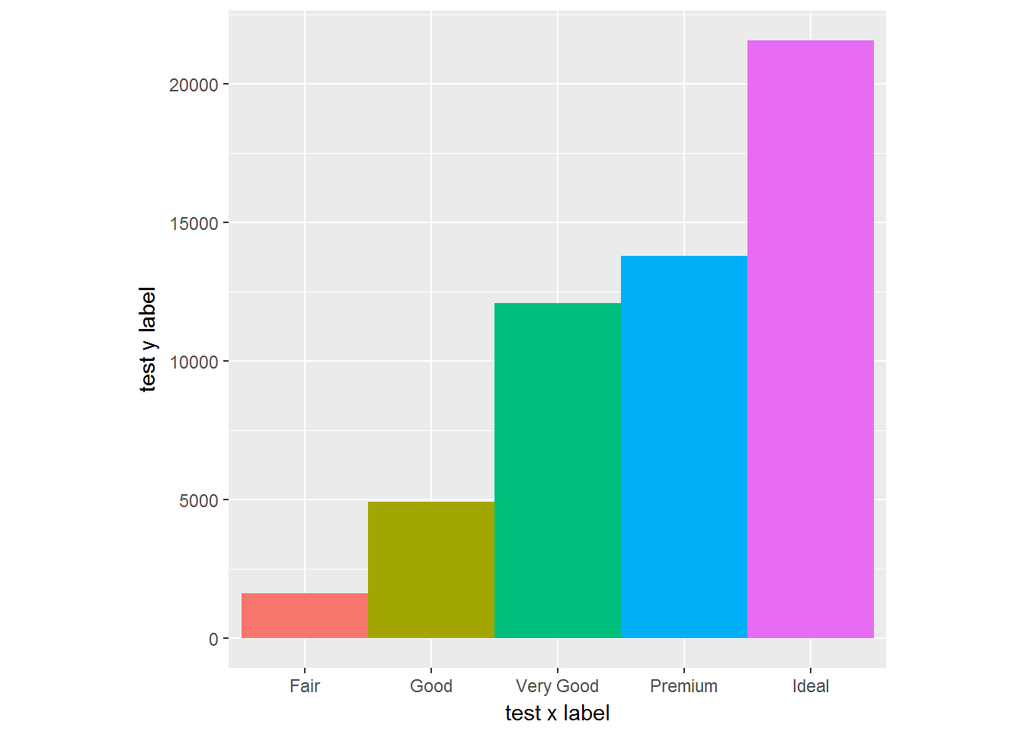

```r
bar2
```

## Q4

1.What does the plot below tell you about the relationship between city and highway mpg? - *Graph shows at what points the city mileage is worse than highway* 2.Why is coord_fixed() important? - *ensures that one unit on the x-axis is the same length as one unit on the y-axis* 3.What does geom_abline() - *Used to draw the slope*

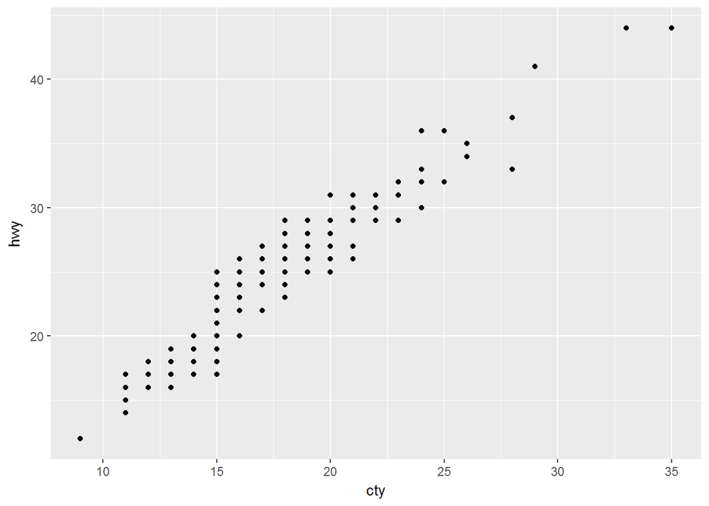

```r
ggplot(data = mpg, mapping = aes(x = cty, y = hwy)) +
  geom_point()
```

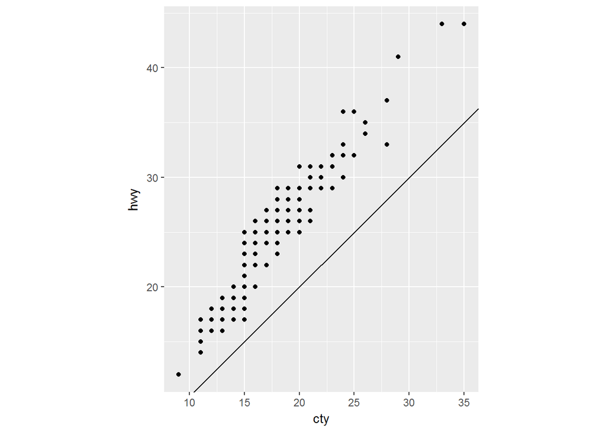

```r
ggplot(data = mpg, mapping = aes(x = cty, y = hwy)) +
  geom_point() +
  geom_abline() +
  coord_fixed()
```

# 4.4

## Q1

my_variable <- 10 my_varıable Variable name should be given exactly as defined, in this case should be my_var**i**able

```r
my_variable <- 10
my_variable
```

```
## [1] 10
```

## Q2

Filtered dataset can be assigned to a variable and that variable can be used in the ggplot

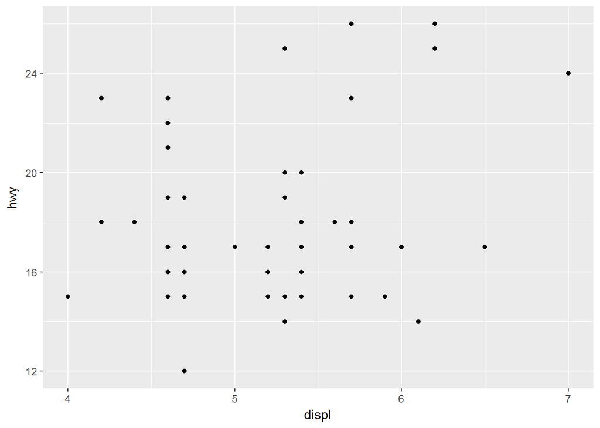

```r
mpg_8 <- mpg %>% filter(cyl == 8)
ggplot(data = mpg_8) + geom_point(mapping = aes(x = displ, y = hwy))
```

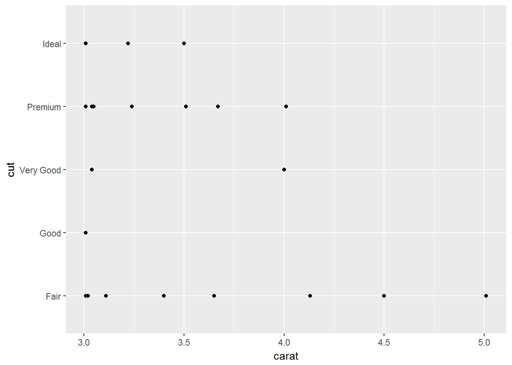

```r
diamond_above3 <- diamonds %>% filter(carat > 3)
ggplot(data = diamond_above3) + geom_point(mapping = aes(x = carat, y = cut))
```

# 5.2.4

## Q1

```r
library(nycflights13)
#1. Had an arrival delay of two or more hours
filter(flights, arr_delay >= 120)
```

```
## # A tibble: 10,200 x 19
##     year month   day dep_time sched_dep_time dep_delay arr_time
##    <int> <int> <int>    <int>          <int>     <dbl>    <int>
##  1  2013     1     1      811            630      101.     1047
##  2  2013     1     1      848           1835      853.     1001
##  3  2013     1     1      957            733      144.     1056
##  4  2013     1     1     1114            900      134.     1447
##  5  2013     1     1     1505           1310      115.     1638
##  6  2013     1     1     1525           1340      105.     1831
##  7  2013     1     1     1549           1445       64.     1912
##  8  2013     1     1     1558           1359      119.     1718
##  9  2013     1     1     1732           1630       62.     2028
## 10  2013     1     1     1803           1620      103.     2008
## # ... with 10,190 more rows, and 12 more variables: sched_arr_time <int>,
## #   arr_delay <dbl>, carrier <chr>, flight <int>, tailnum <chr>,
## #   origin <chr>, dest <chr>, air_time <dbl>, distance <dbl>, hour <dbl>,
## #   minute <dbl>, time_hour <dttm>
```

```r
#2. Flew to Houston (IAH or HOU)
filter(flights, dest=='IAH'|dest=='HOU')
```

```
## # A tibble: 9,313 x 19
##     year month   day dep_time sched_dep_time dep_delay arr_time
##    <int> <int> <int>    <int>          <int>     <dbl>    <int>
##  1  2013     1     1      517            515        2.      830
##  2  2013     1     1      533            529        4.      850
##  3  2013     1     1      623            627       -4.      933
##  4  2013     1     1      728            732       -4.     1041
##  5  2013     1     1      739            739        0.     1104
##  6  2013     1     1      908            908        0.     1228
##  7  2013     1     1     1028           1026        2.     1350
##  8  2013     1     1     1044           1045       -1.     1352
##  9  2013     1     1     1114            900      134.     1447
## 10  2013     1     1     1205           1200        5.     1503
## # ... with 9,303 more rows, and 12 more variables: sched_arr_time <int>,
## #   arr_delay <dbl>, carrier <chr>, flight <int>, tailnum <chr>,
## #   origin <chr>, dest <chr>, air_time <dbl>, distance <dbl>, hour <dbl>,
## #   minute <dbl>, time_hour <dttm>
```

```r
#3. Were operated by United, American, or Delta
filter(flights, carrier %in% c('UA','AA','DL'))
```

```
## # A tibble: 139,504 x 19
##     year month   day dep_time sched_dep_time dep_delay arr_time
##    <int> <int> <int>    <int>          <int>     <dbl>    <int>
##  1  2013     1     1      517            515        2.      830
##  2  2013     1     1      533            529        4.      850
##  3  2013     1     1      542            540        2.      923
##  4  2013     1     1      554            600       -6.      812
##  5  2013     1     1      554            558       -4.      740
##  6  2013     1     1      558            600       -2.      753
##  7  2013     1     1      558            600       -2.      924
##  8  2013     1     1      558            600       -2.      923
##  9  2013     1     1      559            600       -1.      941
## 10  2013     1     1      559            600       -1.      854
## # ... with 139,494 more rows, and 12 more variables: sched_arr_time <int>,
## #   arr_delay <dbl>, carrier <chr>, flight <int>, tailnum <chr>,
## #   origin <chr>, dest <chr>, air_time <dbl>, distance <dbl>, hour <dbl>,
## #   minute <dbl>, time_hour <dttm>
```

```r
#4. Departed in summer (July, August, and September)
filter(flights, month %in% c(7,8,9))
```

```
## # A tibble: 86,326 x 19
##     year month   day dep_time sched_dep_time dep_delay arr_time
##    <int> <int> <int>    <int>          <int>     <dbl>    <int>
##  1  2013     7     1        1           2029      212.      236
##  2  2013     7     1        2           2359        3.      344
##  3  2013     7     1       29           2245      104.      151
##  4  2013     7     1       43           2130      193.      322
##  5  2013     7     1       44           2150      174.      300
##  6  2013     7     1       46           2051      235.      304
##  7  2013     7     1       48           2001      287.      308
##  8  2013     7     1       58           2155      183.      335
##  9  2013     7     1      100           2146      194.      327
## 10  2013     7     1      100           2245      135.      337
## # ... with 86,316 more rows, and 12 more variables: sched_arr_time <int>,
## #   arr_delay <dbl>, carrier <chr>, flight <int>, tailnum <chr>,
## #   origin <chr>, dest <chr>, air_time <dbl>, distance <dbl>, hour <dbl>,
## #   minute <dbl>, time_hour <dttm>
```

```r
#5. Arrived more than two hours late, but didn’t leave late
filter(flights, arr_delay>120 & dep_delay==0)
```

```
## # A tibble: 3 x 19
##    year month   day dep_time sched_dep_time dep_delay arr_time
##   <int> <int> <int>    <int>          <int>     <dbl>    <int>
## 1  2013    10     7     1350           1350        0.     1736
## 2  2013     5    23     1810           1810        0.     2208
## 3  2013     7     1      905            905        0.     1443
## # ... with 12 more variables: sched_arr_time <int>, arr_delay <dbl>,
## #   carrier <chr>, flight <int>, tailnum <chr>, origin <chr>, dest <chr>,
## #   air_time <dbl>, distance <dbl>, hour <dbl>, minute <dbl>,
## #   time_hour <dttm>
```

```r
#6. Were delayed by at least an hour, but made up over 30 minutes in flight
filter(flights, dep_delay>=60 & arr_delay<=dep_delay-30)
```

```
## # A tibble: 2,074 x 19
##     year month   day dep_time sched_dep_time dep_delay arr_time
##    <int> <int> <int>    <int>          <int>     <dbl>    <int>
##  1  2013     1     1     1716           1545       91.     2140
##  2  2013     1     1     2205           1720      285.       46
##  3  2013     1     1     2326           2130      116.      131
##  4  2013     1     3     1503           1221      162.     1803
##  5  2013     1     3     1821           1530      171.     2131
##  6  2013     1     3     1839           1700       99.     2056
##  7  2013     1     3     1850           1745       65.     2148
##  8  2013     1     3     1923           1815       68.     2036
##  9  2013     1     3     1941           1759      102.     2246
## 10  2013     1     3     1950           1845       65.     2228
## # ... with 2,064 more rows, and 12 more variables: sched_arr_time <int>,
## #   arr_delay <dbl>, carrier <chr>, flight <int>, tailnum <chr>,
## #   origin <chr>, dest <chr>, air_time <dbl>, distance <dbl>, hour <dbl>,
## #   minute <dbl>, time_hour <dttm>
```

```r
#7. Departed between midnight and 6am (inclusive)
filter(flights, dep_time>=0000 & dep_time <=0600)
```

```
## # A tibble: 9,344 x 19
##     year month   day dep_time sched_dep_time dep_delay arr_time
##    <int> <int> <int>    <int>          <int>     <dbl>    <int>
##  1  2013     1     1      517            515        2.      830
##  2  2013     1     1      533            529        4.      850
##  3  2013     1     1      542            540        2.      923
##  4  2013     1     1      544            545       -1.     1004
##  5  2013     1     1      554            600       -6.      812
##  6  2013     1     1      554            558       -4.      740
##  7  2013     1     1      555            600       -5.      913
##  8  2013     1     1      557            600       -3.      709
##  9  2013     1     1      557            600       -3.      838
## 10  2013     1     1      558            600       -2.      753
## # ... with 9,334 more rows, and 12 more variables: sched_arr_time <int>,
## #   arr_delay <dbl>, carrier <chr>, flight <int>, tailnum <chr>,
## #   origin <chr>, dest <chr>, air_time <dbl>, distance <dbl>, hour <dbl>,
## #   minute <dbl>, time_hour <dttm>
```